# Dynamic-Reporting-with-R-Markdown

Knit to HTML Demonstration

Jason Ross, Jacob Cochran, and Jonah Withers (contact: Jonah_Withers@fws.gov for issues)

June 02, 2023

# Introduction

This document demonstrates how to render a HTML document using **RMarkdown** ([RMarkdown Cheat Sheet](https://www.rstudio.com/wp-content/uploads/2015/02/rmarkdown-cheatsheet.pdf)) and provides a few helpful links. Unlike Word and PDF documents which are static, rendering HTML files allows you the the ability to incorporate interactive figures, tables, and widgets.

# Tables

Rendered HTML documents support a number of print engines. In this section, we’ll review review and compare several of the more popular table types used.

## Knitr (kable) Package

The Kable package helps you create basic, static tables that are easily rendered in both PDF and HTML outputs.

- Knitr (Kable) Resources:
  - https://cran.r-project.org/web/packages/kableExtra/vignettes/awesome_table_in_html.html
  - https://bookdown.org/yihui/rmarkdown-cookbook/kable.html
  - https://www.rdocumentation.org/packages/knitr/versions/1.42/topics/kable

Table 1. This is a nice table using knitr::kable.

| Samp_Year | Count | Mean_TL_mm | Mean_Wt_g |
| --- | --- | --- | --- |
| 1993 | 37 | 545.33 | NaN |
| 1995 | 12 | 560.75 | 1438.00 |
| 1996 | 11 | 530.27 | 1428.00 |
| 1997 | 145 | 518.11 | 1319.45 |
| 1998 | 97 | 574.36 | 2020.89 |
| 1999 | 52 | 551.50 | 2023.82 |
| 2000 | 29 | 555.90 | 1628.85 |
| 2001 | 6 | 540.00 | 2200.00 |
| 2002 | 21 | 562.95 | 1888.24 |
| 2003 | 17 | 582.35 | 2175.71 |
| 2004 | 10 | 551.90 | 1670.00 |
| 2005 | 15 | 540.33 | 1740.67 |
| 2006 | 23 | 525.13 | 1380.50 |
| 2007 | 36 | 545.28 | 1668.57 |
| 2008 | 19 | 530.00 | 1462.11 |
| 2009 | 33 | 543.24 | 1580.94 |
| 2010 | 98 | 561.82 | 1796.91 |
| 2011 | 186 | 539.26 | 1556.20 |
| 2012 | 44 | 557.84 | 1963.41 |
| 2013 | 109 | 584.15 | 2221.19 |
| 2014 | 158 | 567.89 | 2026.84 |
| 2015 | 134 | 553.07 | 1750.24 |
| 2016 | 90 | 580.48 | 2072.81 |
| 2017 | 109 | 599.65 | 2357.04 |
| 2018 | 50 | 515.30 | 1660.80 |
| 2019 | 63 | 559.18 | 1888.50 |
| 2020 | 38 | 597.92 | 2294.74 |
| 2021 | 1 | 505.00 | NaN |

## KableExtra Package

The **KableExtra package** https://haozhu233.github.io/kableExtra/ is not a table generating package, its a package that allows you to add features to a *kable()* object. Let’s change the look of our table by adding a new style and highlighting some specific rows.

- KableExtra Resources:
  - https://cran.r-project.org/web/packages/kableExtra/vignettes/awesome_table_in_html.html
  - https://bookdown.org/yihui/rmarkdown-cookbook/kableextra.html
  - https://www.rdocumentation.org/packages/kableExtra/versions/1.3.4

Table 2. This is a nice table using kableExtra::kbl.

| Samp_Year | Count | Mean_TL_mm | Mean_Wt_g |
| --- | --- | --- | --- |
| 1993 | 37 | 545.33 | NaN |
| 1995 | 12 | 560.75 | 1438.00 |
| 1996 | 11 | 530.27 | 1428.00 |
| 1997 | 145 | 518.11 | 1319.45 |
| 1998 | 97 | 574.36 | 2020.89 |
| 1999 | 52 | 551.50 | 2023.82 |
| 2000 | 29 | 555.90 | 1628.85 |
| 2001 | 6 | 540.00 | 2200.00 |
| 2002 | 21 | 562.95 | 1888.24 |
| 2003 | 17 | 582.35 | 2175.71 |
| 2004 | 10 | 551.90 | 1670.00 |
| 2005 | 15 | 540.33 | 1740.67 |
| 2006 | 23 | 525.13 | 1380.50 |
| 2007 | 36 | 545.28 | 1668.57 |
| 2008 | 19 | 530.00 | 1462.11 |
| 2009 | 33 | 543.24 | 1580.94 |
| 2010 | 98 | 561.82 | 1796.91 |
| 2011 | 186 | 539.26 | 1556.20 |
| 2012 | 44 | 557.84 | 1963.41 |
| 2013 | 109 | 584.15 | 2221.19 |
| 2014 | 158 | 567.89 | 2026.84 |
| 2015 | 134 | 553.07 | 1750.24 |
| 2016 | 90 | 580.48 | 2072.81 |
| 2017 | 109 | 599.65 | 2357.04 |
| 2018 | 50 | 515.30 | 1660.80 |
| 2019 | 63 | 559.18 | 1888.50 |
| 2020 | 38 | 597.92 | 2294.74 |
| 2021 | 1 | 505.00 | NaN |

## Flextable Package

The **Flextable package** https://ardata-fr.github.io/flextable-book/ is a great option for creating customizable tables that can rendered to Microsoft Word documents, PDFs, or HTML.

- Flextable Resources:
  - https://ardata-fr.github.io/flextable-book/
  - https://cran.r-project.org/web/packages/flextable/flextable.pdf
  - https://davidgohel.github.io/flextable/reference/index.html

Table 3. This is a nice table using the flextable package.

| Samp_Year | Count | Mean_TL_mm | Mean_Wt_g |
| --- | --- | --- | --- |
| 1993 | 37 | 545.33 |  |
| 1995 | 12 | 560.75 | 1,438.00 |
| 1996 | 11 | 530.27 | 1,428.00 |
| 1997 | 145 | 518.11 | 1,319.45 |
| 1998 | 97 | 574.36 | 2,020.89 |
| 1999 | 52 | 551.50 | 2,023.82 |
| 2000 | 29 | 555.90 | 1,628.85 |
| 2001 | 6 | 540.00 | 2,200.00 |
| 2002 | 21 | 562.95 | 1,888.24 |
| 2003 | 17 | 582.35 | 2,175.71 |
| 2004 | 10 | 551.90 | 1,670.00 |
| 2005 | 15 | 540.33 | 1,740.67 |
| 2006 | 23 | 525.13 | 1,380.50 |
| 2007 | 36 | 545.28 | 1,668.57 |
| 2008 | 19 | 530.00 | 1,462.11 |
| 2009 | 33 | 543.24 | 1,580.94 |
| 2010 | 98 | 561.82 | 1,796.91 |
| 2011 | 186 | 539.26 | 1,556.20 |
| 2012 | 44 | 557.84 | 1,963.41 |
| 2013 | 109 | 584.15 | 2,221.19 |
| 2014 | 158 | 567.89 | 2,026.84 |
| 2015 | 134 | 553.07 | 1,750.24 |
| 2016 | 90 | 580.48 | 2,072.81 |
| 2017 | 109 | 599.65 | 2,357.04 |
| 2018 | 50 | 515.30 | 1,660.80 |
| 2019 | 63 | 559.18 | 1,888.50 |
| 2020 | 38 | 597.92 | 2,294.74 |
| 2021 | 1 | 505.00 |  |

## Reactable Package

The **Reactable package** https://glin.github.io/reactable/index.html is the first table we’ll explore that creates an interactive table. This is one of our favorite interactive tables since you can provide the user options to filter or search content within the table. There are several other options you can include as well (grouping, styling, pagination, etc.).

- Reactable Resources:
  - https://glin.github.io/reactable/index.html
  - https://cran.r-project.org/web/packages/reactable/index.html
  - https://www.rdocumentation.org/packages/reactable/versions/0.2.2/topics/reactable

| Samp_Year | Count | Mean_TL_mm | Mean_Wt_g |
| --- | --- | --- | --- |
| 1993 | 37 | 545.33 | NaN |
| 1995 | 12 | 560.75 | 1438 |
| 1996 | 11 | 530.27 | 1428 |
| 1997 | 145 | 518.11 | 1319.45 |
| 1998 | 97 | 574.36 | 2020.89 |
| 1999 | 52 | 551.5 | 2023.82 |
| 2000 | 29 | 555.9 | 1628.85 |
| 2001 | 6 | 540 | 2200 |
| 2002 | 21 | 562.95 | 1888.24 |
| 2003 | 17 | 582.35 | 2175.71 |

[output cut: 18 more lines]

# Figures

Similar to tables, figures rendered in HTML documents can provide more user capabilities than PDF and Word documents. In this section, we’ll review and compare a few popular figure types.

## Line graphs

### ggplot2

Lets start with a basic line graph using the ggplot2 package to see what the figure would look like if we produced it for a PDF or Word document.

- ggplot2 Resources:
  - https://ggplot2.tidyverse.org/reference/aes.html
  - https://ggplot2-book.org/toolbox.html
  - https://bookdown.dongzhuoer.com/hadley/ggplot2-book/aes.html

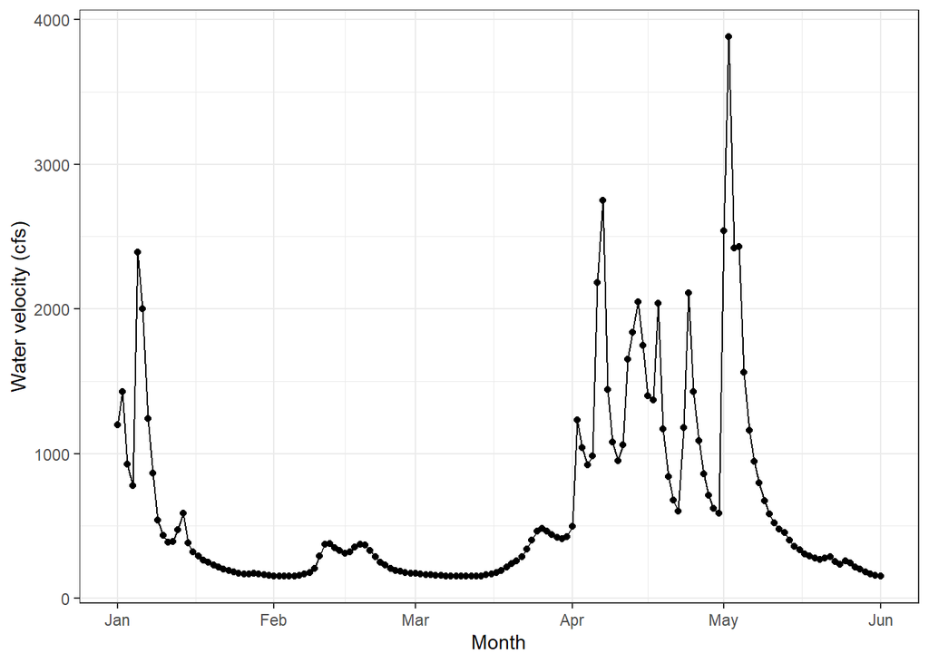

### Dygraphs

The dygraphs R package https://rstudio.github.io/dygraphs/ allows you to build figures with interactive capabilities which can improve the experience of the user. Notice the values presented in the upper right corner of the figure when you hover your mouse over a point on the graph. Also try using the slider along the bottom to zoom in to specific dates along the x-axis.

- Dygraphs Resource:
  - https://rstudio.github.io/dygraphs/
  - https://r-graph-gallery.com/316-possible-inputs-for-the-dygraphs-library.html

[interactive chart not shown]

### R Shiny

Before rendering our code, we need to change our YAML to include *runtime: shiny*.

- RShiny Resource:
  - https://www.rstudio.com/products/shiny/

## Maps

Now lets explore some options for creating maps in R Markdown.

### ggplot2

We can start with a static map using the ggplot2 package. We will make a map of the lower 48 and overlay a gray point where NCTC is located.

- ggplot2 Resources:
  - https://ggplot2.tidyverse.org/reference/aes.html
  - https://ggplot2-book.org/maps.html
  - https://bookdown.dongzhuoer.com/hadley/ggplot2-book/aes.html

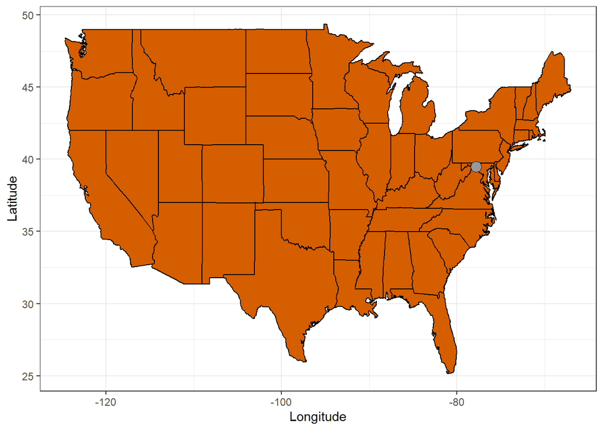

### Leaflet

Again, lets create a point at NCTC but this time we’ll create an interactive map using the **Leaflet** package https://rstudio.github.io/leaflet/. The Leaflet package is a very popular package used to create interactive maps but know there are others out there (plotly, highcharter, ggiraph, tmap, mapdeck, etc.).

- Leaflet Resources:
  - https://cran.r-project.org/web/packages/leaflet/leaflet.pdf
  - https://bookdown.org/nicohahn/making_maps_with_r5/docs/leaflet.html

[interactive chart not shown]

### Mapview

Another popular package used to create interactive maps is the **mapview** package https://r-spatial.github.io/mapview/.

- mapview Resources:
  - https://www.rdocumentation.org/packages/mapview/versions/2.11.0/topics/mapView
  - https://cran.r-project.org/web/packages/mapview/mapview.pdf
  - https://bookdown.org/nicohahn/making_maps_with_r5/docs/mapview.html

[interactive chart not shown]